# data scrapping

## Install Libraries

```r
#install.packages("rtweet")
#install.packages("tidytext")
#install.packages("ggraph")
```

# Text Preprocessing

## Call Libraries and Autentication Setup

```r
library(rtweet)
```

```r
library(ggplot2)
library(dplyr)
library(tidytext)
library(igraph)
library(ggraph)
auth_setup_default()
```

```
## Using default authentication available.
```

```
## Reading auth from 'C:\Users\Randi\AppData\Roaming/R/config/R/rtweet/default.rds'
```

## Scrapping Twitter

```r
#mlops_tweets = search_tweets(q="#mlops",n=20000, lang="en", include_rts=FALSE)

#head(mlops_tweets)
```

### Source of Topics

Future Today Institute: https://futuretodayinstitute.com/trends/

```r
mlops_tweets = search_tweets(q="mlops+business", n=100000, lang="en",include_rts=FALSE)

head(mlops_tweets)
```

```
## # A tibble: 6 × 43
##   created_at               id id_str        full_…¹ trunc…² displ…³ entities
##   <dttm>                <dbl> <chr>         <chr>   <lgl>     <dbl> <list>
## 1 2022-11-26 21:30:17 1.60e18 159651166591… "#AI t… FALSE       214 <named list>
## 2 2022-11-25 19:36:00 1.60e18 159612051630… "as yo… FALSE       280 <named list>
## 3 2022-11-25 00:04:40 1.60e18 159582573969… "4️⃣ Gre… FALSE       126 <named list>
## 4 2022-11-25 00:04:39 1.60e18 159582573705… "2️⃣ Imp… FALSE       151 <named list>
## 5 2022-11-24 23:00:13 1.60e18 159580952437… "Some … FALSE       279 <named list>
## 6 2022-11-24 19:26:52 1.60e18 159575583223… "We're… FALSE       279 <named list>
## # … with 36 more variables: metadata <list>, source <chr>,
## #   in_reply_to_status_id <dbl>, in_reply_to_status_id_str <chr>,
## #   in_reply_to_user_id <dbl>, in_reply_to_user_id_str <chr>,
## #   in_reply_to_screen_name <chr>, geo <list>, coordinates <list>,
## #   place <list>, contributors <lgl>, is_quote_status <lgl>,
## #   retweet_count <int>, favorite_count <int>, favorited <lgl>,
## #   retweeted <lgl>, possibly_sensitive <lgl>, lang <chr>, …
```

```r
# mlops_mlops_2 = search_tweets(q="mlopsmlops",n=10000, lang="en", include_rts=FALSE)

#head(mlops_mlops_2)
```

## Cek Emoji

```r
head(mlops_tweets$text)
```

```
## [1] "#AI tip of the day\n\n✅Find a growth business case\n✅ Tag data\n✅ Have talent/partner\n✅ Have platform\n✅ Run #ML Experiments\n\n⁉️ But long-term success comes from #MLOps and #ModelOps\n\nhttps://t.co/c1z66Cn42g #DrivingDig"
## [2] "as your business and team grow, you need support handling employment legislation, talent acquisition, and, most importantly, keeping staff feeling valued and engaged. #gainwithstewartilondanga #AR #AI #MR #XR #Fifa22 #QATAR22 #Web3 #SaaS #AIoT #MLOps #Space #DevOps #fintech #Meta"
## [3] "4️⃣ Greater scalability - The MLOps platform will enable you to scale your machine learning operations as your business grows."
## [4] "2️⃣ Improved accuracy - The MLOps platform will help ensure that your models are always up-to-date and accurate, resulting in better business outcomes."
## [5] "Some of the greatest books for machine learning:\n\n1/ Business DS\n2/ Algorithm Design\n3/ Introduction to MLOPs\n4/ Machine Learning Design Patterns\n5/ TensorFlow Deep Learning Projects\n6/ An Introduction to Statistical Learning\n7/ Deep Learning for Coders with Fastai &amp; PyTorch"
## [6] "We're super bullish on making AI work for society and business.\n\nNo B.S, sheer hard tested AI in the real world.\n\nWhether it is solving the hard problem of Energy crisis with AI, or hardest problem in healthcare or fundamental problems with AI (LLM, MLOps…https://t.co/PHn5g1YsWm"
```

## Eliminate URL in text

```r
mlops_tweets$stripped_text = gsub("http[^[:space:]]*","", mlops_tweets$text)

mlops_tweets$stripped_text = gsub("https[^[:space:]]*","", mlops_tweets$stripped_text)

mlops_tweets$stripped_text = gsub("[^[:alpha:][:space:]]*","", mlops_tweets$stripped_text)

head(mlops_tweets$stripped_text, n=10)
```

```
##  [1] "AI tip of the day\n\nFind a growth business case\n Tag data\n Have talentpartner\n Have platform\n Run ML Experiments\n\n But longterm success comes from MLOps and ModelOps\n\n DrivingDig"
##  [2] "as your business and team grow you need support handling employment legislation talent acquisition and most importantly keeping staff feeling valued and engaged gainwithstewartilondanga AR AI MR XR Fifa QATAR Web SaaS AIoT MLOps Space DevOps fintech Meta"
##  [3] " Greater scalability  The MLOps platform will enable you to scale your machine learning operations as your business grows"
##  [4] " Improved accuracy  The MLOps platform will help ensure that your models are always uptodate and accurate resulting in better business outcomes"
##  [5] "Some of the greatest books for machine learning\n\n Business DS\n Algorithm Design\n Introduction to MLOPs\n Machine Learning Design Patterns\n TensorFlow Deep Learning Projects\n An Introduction to Statistical Learning\n Deep Learning for Coders with Fastai amp PyTorch"
##  [6] "Were super bullish on making AI work for society and business\n\nNo BS sheer hard tested AI in the real world\n\nWhether it is solving the hard problem of Energy crisis with AI or hardest problem in healthcare or fundamental problems with AI LLM MLOps"
##  [7] "YOU SPOKE WE LISTENED \n\nThank you for the feedbackCome learn how organisations are harnessing DataOps AnalyticOps MLOps and AIOps in March  at our next event OpsWorld DataCentric Operations for Business Value  BOOK your seat TODAY  "
##  [8] "A business showing that it is inclusive and supportive of minority groups can help members of those groups to feel welcomed gainwithstewartilondanga AR AI MR XR Fifa QATAR Web SaaS AIoT MLOps Space DevOps fintech Metaverse VirtualReality SlackFrontiers PS"
##  [9] "With any new change to Google Business Profile early adoption will put you ahead of the pack they can make your business more attractive to prospective local customers gainwithstewartilondanga AR AI MR XR Fifa QATAR Web SaaS AIoT MLOps Space DevOps fintech"
## [10] "To keep up to date with what new features are becoming available and who is eligible for them visit Googles Business Profile announcements page gainwithstewartilondanga AR AI MR XR Fifa QATAR Web SaaS AIoT MLOps Space DevOps fintech Metaverse PS Apple"
```

## CASE-FOLDING

```r
mlops_tweets_clean = mlops_tweets %>%
  dplyr::select(stripped_text) %>%
  unnest_tokens(word, stripped_text)

tail(mlops_tweets_clean, n=20)
```

```
## # A tibble: 20 × 1
##    word
##    <chr>
##  1 factor
##  2 is
##  3 embracing
##  4 your
##  5 limitations
##  6 especially
##  7 when
##  8 doing
##  9 mlmlops
## 10 at
## 11 a
## 12 reasonable
## 13 scale
## 14 a
## 15 few
## 16 successful
## 17 examples
## 18 that
## 19 we
## 20 found
```

from the looks of the transformation, the stripped_text column just got transformed in terms of:

- Changing uppercase to lowercase
- Eliminate punctuation
- Parse words into word and convert to rows

## Tokenizing

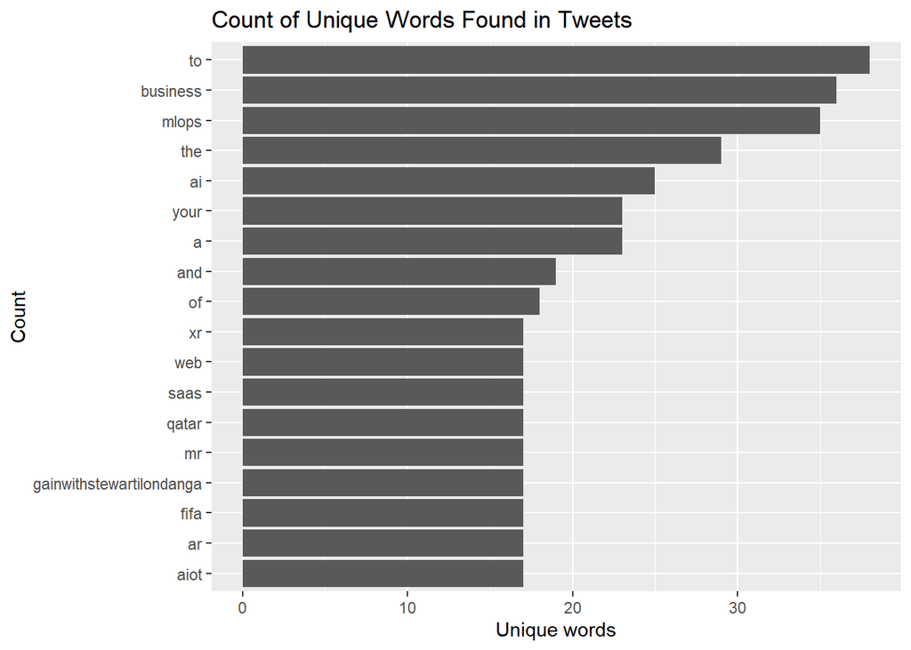

```r
mlops_tweets_clean %>%
  count(word, sort=TRUE) %>%
  top_n(15)%>%
  mutate(word=reorder(word,n))%>%
  ggplot(aes(x=word, y=n))+geom_col()+xlab(NULL)+coord_flip()+labs(x="Count",y="Unique words",title="Count of Unique Words Found in Tweets")
```

In the case folding case, it seems that the data already tokenized, so here it assumed as the graphical representation.

## Stop Word Removal

Meaning of lexicon: https://www.vocabulary.com/dictionary/lexicon Lexicon contained in this dataset: https://juliasilge.github.io/tidytext/reference/stop_words.html

```r
data("stop_words")

head(stop_words)
```

```
## # A tibble: 6 × 2
##   word      lexicon
##   <chr>     <chr>
## 1 a         SMART
## 2 a's       SMART
## 3 able      SMART
## 4 about     SMART
## 5 above     SMART
## 6 according SMART
```

```r
nrow(mlops_tweets_clean)
```

```
## [1] 1261
```

```r
cleaned_tweet_words = mlops_tweets_clean %>%
  anti_join(stop_words) # is antijoin function is to eliminate similar data between 2 dataset?
nrow(cleaned_tweet_words)
```

```
## [1] 745
```

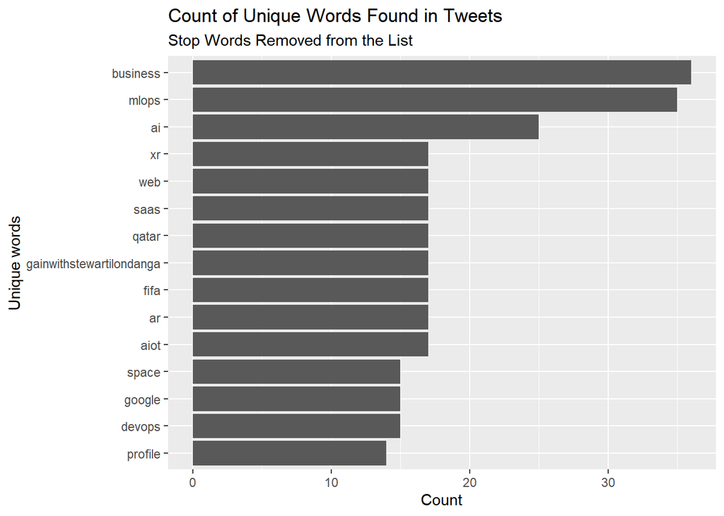

```r
cleaned_tweet_words %>%
  count(word, sort=TRUE) %>%
  top_n(15)%>%
  mutate(word=reorder(word,n))%>%
  ggplot(aes(x=word,y=n))+
  geom_col()+
  xlab(NULL)+
  coord_flip()+
  labs(y="Count",x="Unique words",
       title="Count of Unique Words Found in Tweets",
       subtitle="Stop Words Removed from the List")
```

## N-Gramming

```r
#install.packages("widyr")
library(widyr)
mlops_tweets_paired_words = mlops_tweets %>%
  dplyr::select(stripped_text)%>%
  unnest_tokens(paired_words, stripped_text,token="ngrams",n=2)

mlops_tweets_paired_words%>%
  count(paired_words, sort=TRUE)
```

```
## # A tibble: 909 × 2
##    paired_words                    n
##    <chr>                       <int>
##  1 ai mr                          17
##  2 aiot mlops                     17
##  3 ar ai                          17
##  4 fifa qatar                     17
##  5 gainwithstewartilondanga ar    17
##  6 mr xr                          17
##  7 qatar web                      17
##  8 saas aiot                      17
##  9 web saas                       17
## 10 xr fifa                        17
## # … with 899 more rows
```

```r
mlops_tweets_separated_words <- mlops_tweets_paired_words %>%
  tidyr::separate(paired_words,c("word1","word2"),sep=" ")

mlops_tweets_filtered <- mlops_tweets_separated_words  %>%
  filter(!word1%in%stop_words$word) %>%
  filter(!word2%in%stop_words$word)

mlops_words_counts <- mlops_tweets_filtered  %>%
  count(word1,word2,sort=TRUE)

head(mlops_tweets_separated_words)
```

```
## # A tibble: 6 × 2
##   word1 word2
##   <chr> <chr>
## 1 ai    tip
## 2 tip   of
## 3 of    the
## 4 the   day
## 5 day   find
## 6 find  a
```

## Interpretasi

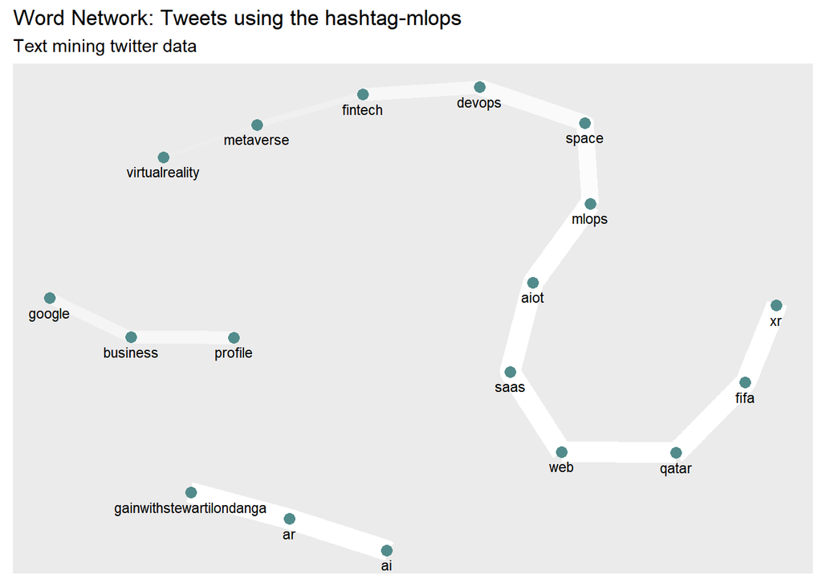

```r
mlops_words_counts  %>%
  filter(n>=5) %>%
  graph_from_data_frame() %>%
  ggraph(layout="fr") +
  geom_edge_link(aes(width = n, edge_alpha = n), show.legend = FALSE,edge_colour = "white")+
  geom_node_point(color="darkslategray4",size=3)+
  geom_node_text(aes(label=name),vjust=1.8,size=3)+
  labs(title="Word Network: Tweets using the hashtag-mlops",
  subtitle="Text mining twitter data",
  x="",y="")
```

MLOps itself is the approach to bring management aspect to the deployment of machine learning in business process. It usually used to bring collaboration, deployment, and manage lifecycle of machine learning model. There is interest to oversee the scope of the implementation in terms of business so the keyword used is mlops+business. This result displayed as Word Network graph which show the relation between words and the frequencies it appears (for each combination of 2 words). Here the minimum frequency is set to 5.

The result show that mlops likely have strong relationship with space and IoT directly since the implementation itself may leverage result yielded in IoT and Space field by making model more robust and relevant to the current environment. In terms of business, there is fintech which indirectly related to mlops so it may be assumed that financial technology industries is the closest business that utilize MLOps approach that may be true for cases such as churn prediction, credit risk analysis, etc.

The unrelevant information involved is like fifa and qatar since after brief inspection, it comes from the hashtags used in the post that most likely used to leverage the topics eventhou it wasn’t relevant.